# Polarization and Sorting- try

```r
library(tidyverse)
library(haven)
library(here)
library(srvyr)
library(readr)
```

```r
anes_work <- read_csv("anes_working_data.csv")
```

```r
anes_svy <- as_survey_design(anes_work, weights = weights)

#All variables are either type 0 or not in the 1970 survey. Full sample data used

#Stratum and PSU ID Variables not referenced in the code book, and we don't know
#how to construct them
```

## Question 1

Are voters better “sorted” into ideologies than in the past, and if this is true, does the trend have a clear beginning or end?

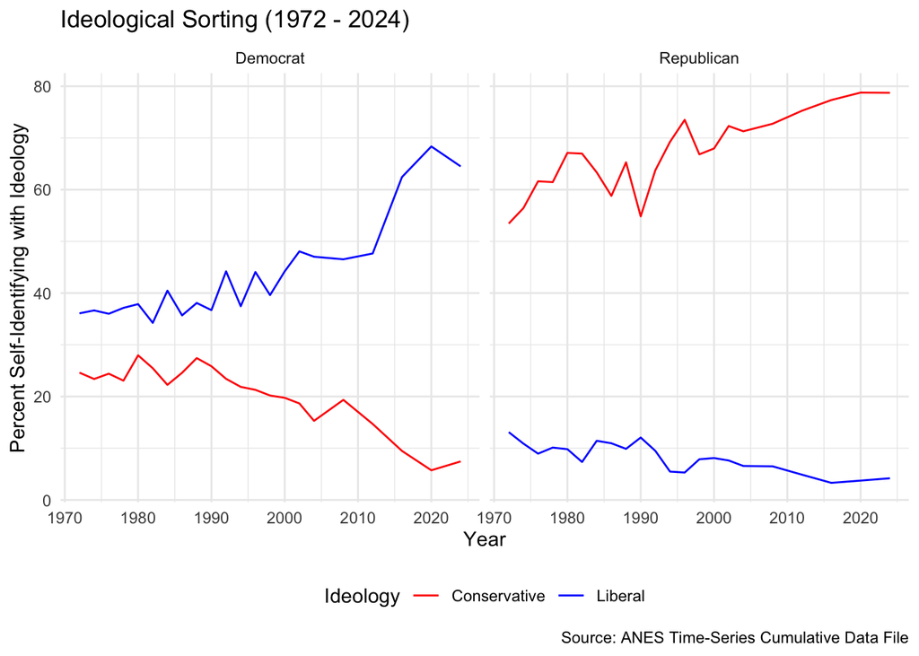

```r
#Ideology x Party Identification

ideo_party <- anes_svy |>
  group_by(year, party) |>
  summarize(lib_pct = 100 * mean(lib_i, na.rm = T),
            con_pct = 100 * mean(con_i, na.rm = T)) |>
  filter(party %in% c("Democrat", "Republican")) |>
  drop_na()

ggplot(ideo_party, aes(x = year)) +
  facet_wrap(~party) +
  geom_line(aes(y = con_pct, colour = "Conservative")) +
  geom_line(aes(y = lib_pct, colour = "Liberal")) +
  scale_color_manual(values = c("Conservative" = "red", "Liberal" = "blue")) +
  theme_minimal() +
  labs(title = "Ideological Sorting (1972 - 2024)",
       x = "Year",
       y = "Percent Self-Identifying with Ideology",
       caption = "Source: ANES Time-Series Cumulative Data File",
       colour = "Ideology") +
  theme(legend.position = "bottom")
```

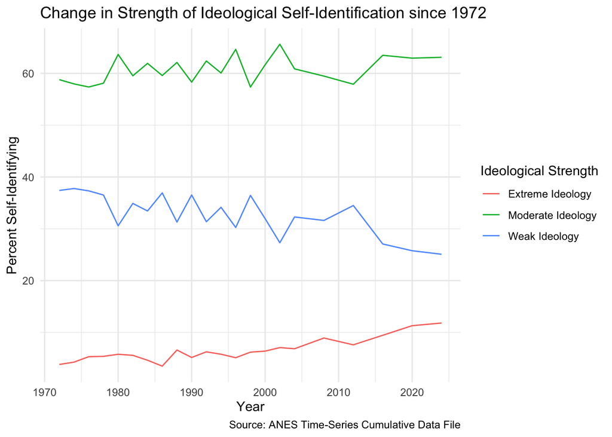

```r
#Change in Ideological Strength

istrength_df <- anes_svy |>
  group_by(year) |>
  summarize(exti_pct = 100 * mean(exti_i, na.rm = T),
            modi_pct = 100 * mean(modi_i, na.rm = T),
            weaki_pct = 100 * mean(weaki_i, na.rm = T)) |>
  drop_na()

ggplot(istrength_df, aes(x = year)) +
  geom_line(aes(y = exti_pct, colour = "Extreme Ideology")) +
  geom_line(aes(y = modi_pct, colour = "Moderate Ideology")) +
  geom_line(aes(y = weaki_pct, colour = "Weak Ideology")) +
  theme_minimal() +
  labs(title = "Change in Strength of Ideological Self-Identification since 1972",
       x = "Year",
       y = "Percent Self-Identifying",
       caption = "Source: ANES Time-Series Cumulative Data File",
       colour = "Ideological Strength")
```

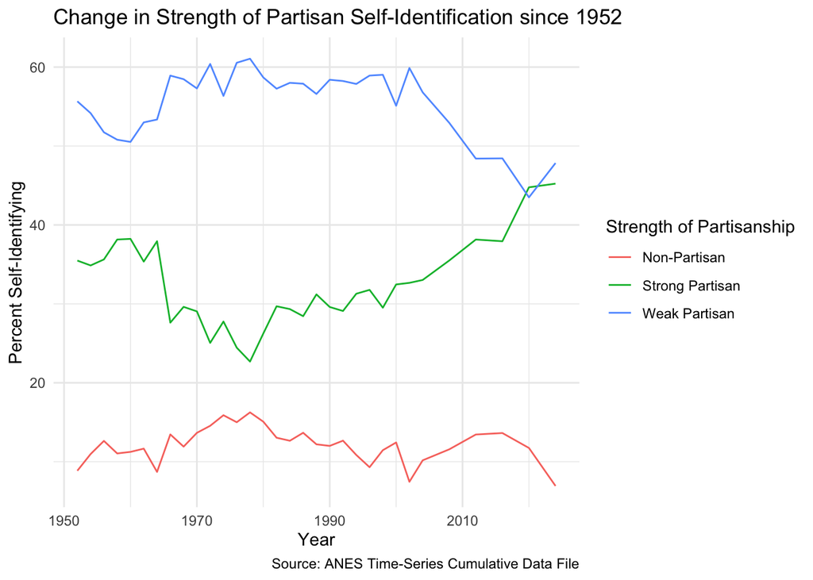

```r
#Change in Partisan Strength

pstrength_df <- anes_svy |>
  group_by(year) |>
  summarize(strongp_pct = 100 * mean(strongp_i, na.rm = T),
            weakp_pct = 100 * mean(weakp_i, na.rm = T),
            nonp_pct = 100 * mean(nonp_i, na.rm = T))|>
  drop_na()


ggplot(pstrength_df, aes(x = year)) +
  geom_line(aes(y = strongp_pct, colour = "Strong Partisan")) +
  geom_line(aes(y = weakp_pct, colour = "Weak Partisan")) +
  geom_line(aes(y = nonp_pct, colour = "Non-Partisan")) +
  theme_minimal() +
  labs(title = "Change in Strength of Partisan Self-Identification since 1952",
       x = "Year",
       y = "Percent Self-Identifying",
       caption = "Source: ANES Time-Series Cumulative Data File",
       colour = "Strength of Partisanship")
```

Ideological sorting appears, with far more Democrats identifying as liberal and Republicans identifying as conservative in 2024 than in 1972. There are also more extreme Democrats and Republicans, but many of these extreme partisans do not identify as extremely liberal or conservative. The trend of increasingly polarized partisanship seems to have taken off around 2001, possibly as a reaction to the 9/11 attacks, and it continues in the present day.

## Question 2

Do trends in polarization and sorting relate to personal characteristics, such as education, gender, race, or income?

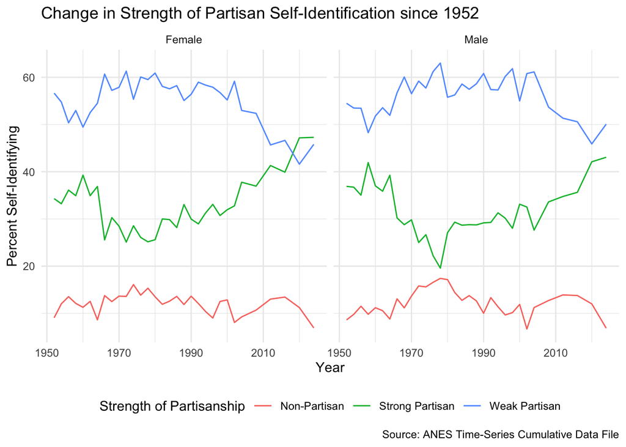

```r
#Partisan strength by gender

pstrength_gender <- anes_svy |>
  group_by(year, gender) |>
  summarize(strongp_pct = 100 * mean(strongp_i, na.rm = T),
            weakp_pct = 100 * mean(weakp_i, na.rm = T),
            nonp_pct = 100 * mean(nonp_i, na.rm = T))|>
  drop_na()

ggplot(pstrength_gender, aes(x = year)) +
  facet_wrap(~gender) +
  geom_line(aes(y = strongp_pct, colour = "Strong Partisan")) +
  geom_line(aes(y = weakp_pct, colour = "Weak Partisan")) +
  geom_line(aes(y = nonp_pct, colour = "Non-Partisan")) +
  theme_minimal() +
  labs(title = "Change in Strength of Partisan Self-Identification since 1952",
       x = "Year",
       y = "Percent Self-Identifying",
       caption = "Source: ANES Time-Series Cumulative Data File",
       colour = "Strength of Partisanship") +
  theme(legend.position = "bottom")
```

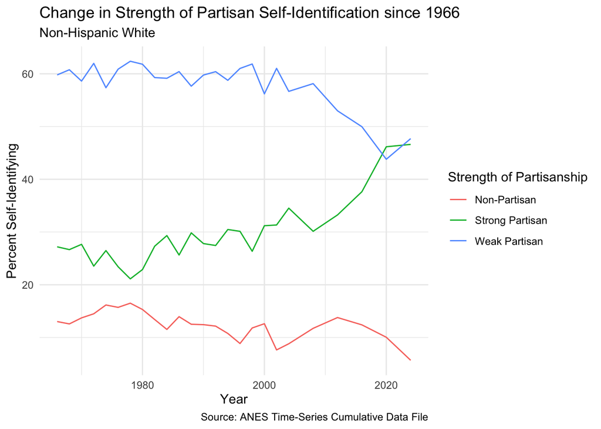

```r
#Partisan strength by race-ethnicity

pstrength_raceeth <- anes_svy |>
  group_by(year, raceeth) |>
  summarize(strongp_pct = 100 * mean(strongp_i, na.rm = T),
            weakp_pct = 100 * mean(weakp_i, na.rm = T),
            nonp_pct = 100 * mean(nonp_i, na.rm = T))|>
  filter(raceeth != "Other non-Hispanic") |>
  filter(year >= 1966) |>
  drop_na()

pstrength_raceeth |>
  filter(raceeth == "White non-Hispanic") |>
  ggplot(aes(x = year)) +
  geom_line(aes(y = strongp_pct, colour = "Strong Partisan")) +
  geom_line(aes(y = weakp_pct, colour = "Weak Partisan")) +
  geom_line(aes(y = nonp_pct, colour = "Non-Partisan")) +
  theme_minimal() +
  labs(title = "Change in Strength of Partisan Self-Identification since 1966",
       subtitle = "Non-Hispanic White",
       x = "Year",
       y = "Percent Self-Identifying",
       caption = "Source: ANES Time-Series Cumulative Data File",
       colour = "Strength of Partisanship")
```

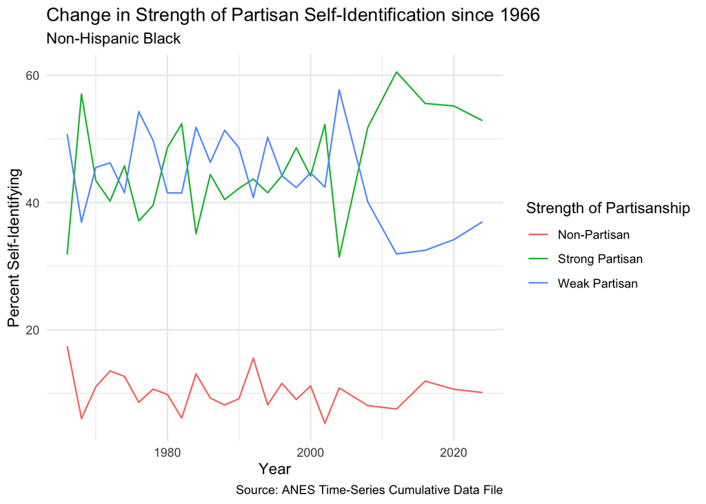

```r
pstrength_raceeth |>
  filter(raceeth == "Black non-Hispanic") |>
  ggplot(aes(x = year)) +
  geom_line(aes(y = strongp_pct, colour = "Strong Partisan")) +
  geom_line(aes(y = weakp_pct, colour = "Weak Partisan")) +
  geom_line(aes(y = nonp_pct, colour = "Non-Partisan")) +
  theme_minimal() +
  labs(title = "Change in Strength of Partisan Self-Identification since 1966",
       subtitle = "Non-Hispanic Black",
       x = "Year",
       y = "Percent Self-Identifying",
       caption = "Source: ANES Time-Series Cumulative Data File",
       colour = "Strength of Partisanship")
```

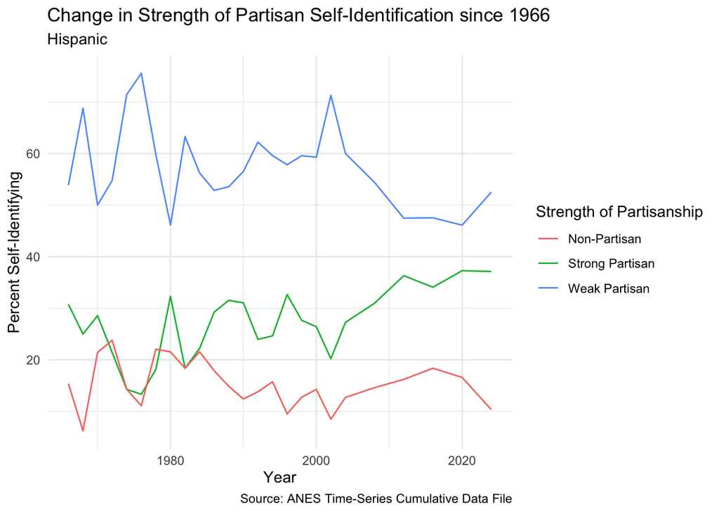

```r
pstrength_raceeth |>
  filter(raceeth == "Hispanic") |>
  ggplot(aes(x = year)) +
  geom_line(aes(y = strongp_pct, colour = "Strong Partisan")) +
  geom_line(aes(y = weakp_pct, colour = "Weak Partisan")) +
  geom_line(aes(y = nonp_pct, colour = "Non-Partisan")) +
  theme_minimal() +
  labs(title = "Change in Strength of Partisan Self-Identification since 1966",
       subtitle = "Hispanic",
       x = "Year",
       y = "Percent Self-Identifying",
       caption = "Source: ANES Time-Series Cumulative Data File",
       colour = "Strength of Partisanship")
```

Women seem to have experienced partisan polarization to a slightly greater extent than men, though it is not clear whether this relationship is significant. From 1952 to 2024, the percent of women that identify as strong partisans increased by 13 percentage points, while the percent of men that identify as strong partisans increased by 6 percentage points.

## Question 3

Do the results of this analysis differ depending on how you define ideology?

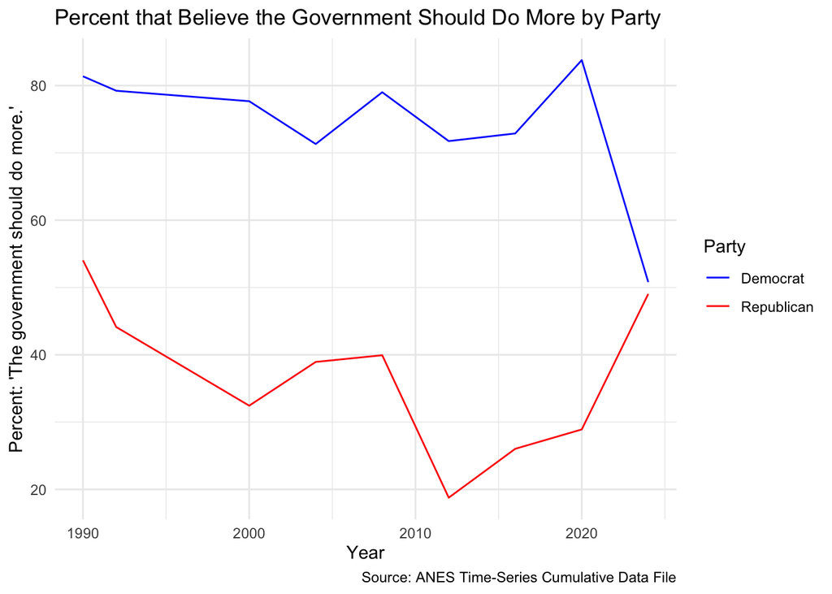

```r
#The government should do more.

lessmore_party <- anes_svy |>
  group_by(year, party) |>
  summarize(gmore_pct = 100 * mean(gmore_i, na.rm = T)) |>
  filter(party %in% c("Democrat", "Republican")) |>
  drop_na()

ggplot(lessmore_party, aes(x = year, y = gmore_pct, colour = party)) +
  geom_line() +
  theme_minimal() +
  scale_color_manual(values = c("Republican" = "red", "Democrat" = "blue")) +
  labs(title = "Percent that Believe the Government Should Do More by Party",
       x = "Year",
       y = "Percent: 'The government should do more.'",
       caption = "Source: ANES Time-Series Cumulative Data File",
       colour = "Party")
```

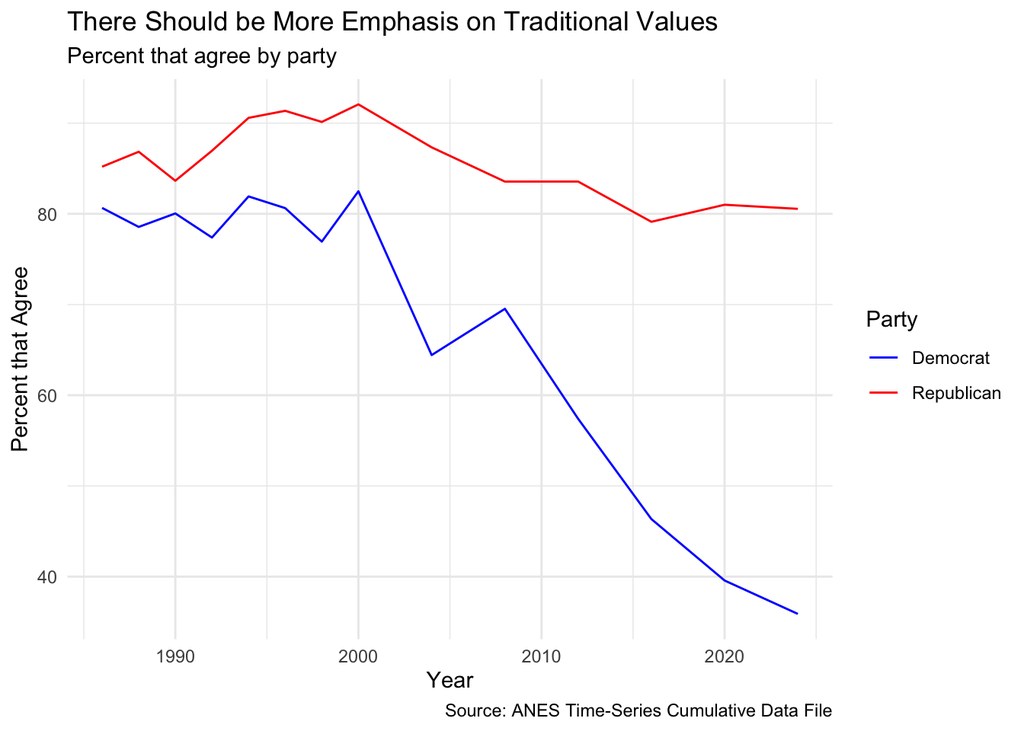

```r
#Agree: More traditional values

tradagree_party <- anes_svy |>
  group_by(year, party) |>
  summarize(tagr_pct = 100 * mean(tagr_i, na.rm = T)) |>
  filter(party %in% c("Democrat", "Republican")) |>
  drop_na()

ggplot(tradagree_party, aes(x = year, y = tagr_pct, colour = party)) +
  geom_line() +
  theme_minimal() +
  scale_color_manual(values = c("Republican" = "red", "Democrat" = "blue")) +
  labs(title = "There Should be More Emphasis on Traditional Values",
       subtitle = "Percent that agree by party",
       x = "Year",
       y = "Percent that Agree",
       caption = "Source: ANES Time-Series Cumulative Data File",
       colour = "Party")
```

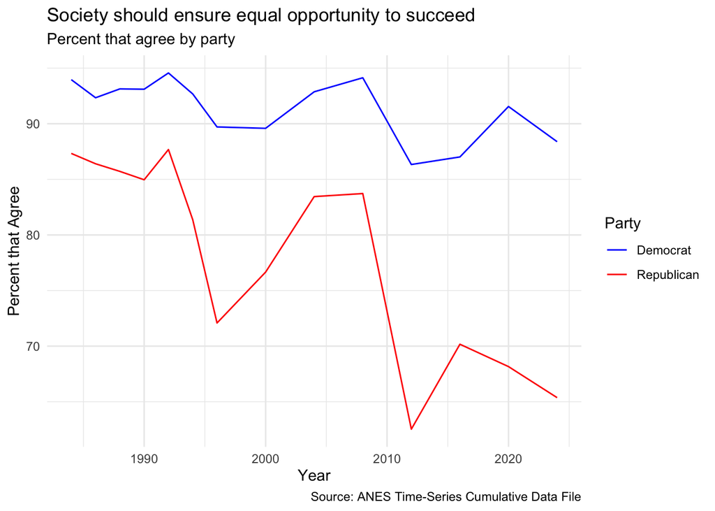

```r
#Agree: Society should ensure equal opportunities

eqagree_party <- anes_svy |>
  group_by(year, party) |>
  summarize(eqagr_pct = 100 * mean(eqagr_i, na.rm = T)) |>
  filter(party %in% c("Democrat", "Republican")) |>
  drop_na()

ggplot(eqagree_party, aes(x = year, y = eqagr_pct, colour = party)) +
  geom_line() +
  theme_minimal() +
  scale_color_manual(values = c("Republican" = "red", "Democrat" = "blue")) +
  labs(title = "Society should ensure equal opportunity to succeed",
       subtitle = "Percent that agree by party",
       x = "Year",
       y = "Percent that Agree",
       caption = "Source: ANES Time-Series Cumulative Data File",
       colour = "Party")
```

Policy connections to political parties are based on [this article](https://dk.usembassy.gov/usa-i-skolen/presidential-elections-and-the-american-political-system/) written by the US Embassy.

Given party platforms, it is expected that Democrats should support bigger government and Republicans limited government. While this expectation holds in the data, since 2020, the percent of Republicans and Democrats that believe the government should do more has almost converged at 50%. This is evidence against an idea of partisan sorting, with respect to policy.

Given party platforms, it is expect that Republicans should support traditionalism, while Democrats should support progressive values. Although both parties saw a decrease in the percent that believed in traditionalism over time, this decrease was much more dramatic for Democrats. The expanding gap between the parties supports the idea that partisan sorting has occurred.

Given party platforms, it is expected that Democrats will place a higher value on egalitarianism, and the role of the government and society in ensuring it, than Republicans. While this relationship holds in the graph, Democrats do not seem to increasingly agree with the statement overtime, as their platform suggests. Rather, it seems that the value of egalitarianism greatly decreased among Republicans and only decreased slightly among Democrats.

In conclusion, using measures of beliefs regarding the role of government does not support a partisan sorting hypothesis, but social beliefs do seem to follow trends that sorting would predict.

## Question 4

Is there evidence of an increase in dislike for the opposing ideology or partisan group?

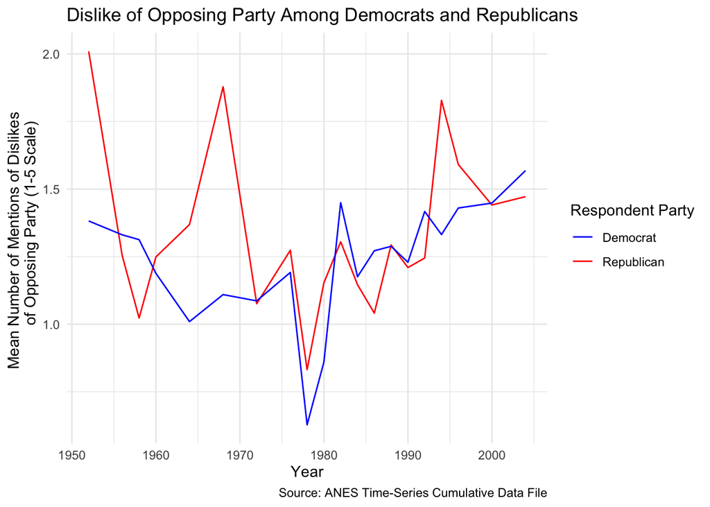

```r
dislike_dem <- anes_svy |>
  filter(party == "Democrat") |>
  group_by(year) |>
  summarize(rdlike_pct = mean(r_dislike, na.rm = T)) |>
  drop_na()

dislike_rep <- anes_svy |>
  filter(party == "Republican") |>
  group_by(year) |>
  summarize(ddlike_pct = mean(d_dislike, na.rm = T)) |>
  drop_na()

ggplot(dislike_rep, aes(x = year)) +
  geom_line(aes(y = ddlike_pct, colour = "Republican")) +
  geom_line(aes(x = year, y = rdlike_pct, colour = "Democrat"), dislike_dem) +
  theme_minimal() +
  scale_color_manual(values = c("Republican" = "red", "Democrat" = "blue")) +
  labs(title = "Dislike of Opposing Party Among Democrats and Republicans",
       x = "Year",
       y = "Mean Number of Mentions of Dislikes
       of Opposing Party (1-5 Scale)",
       caption = "Source: ANES Time-Series Cumulative Data File",
       colour = "Respondent Party")
```

Although data are not available past 2004, between 1952 and 2004, there does not seem to be any consisting increasing or decreasing trend in each parties likes or dislikes of the other. The most visible relationship in the graph is that Republicans number of dislikes mentioned tend to be higher than Democrats, though this pattern often does not hold.